# Analysis assignment, Hodges Ward Elliot

```python
import pandas as pd
import os
import numpy as np
import geopandas as gpd
from shapely.geometry import Point

import matplotlib.pyplot as plt
import matplotlib.colors as colors
from matplotlib.ticker import LogFormatter

from bokeh.plotting import figure
from bokeh.models import WMTSTileSource,ColumnDataSource,ColorBar,Label
from bokeh.io import output_notebook, show
from bokeh.models.tools import HoverTool
from bokeh.transform import linear_cmap,factor_cmap,log_cmap
from bokeh.models import FixedTicker
from bokeh.tile_providers import get_provider, Vendors

from custom_functions import *

output_notebook()
```

## Read in the data

```python
pluto_data = pd.read_csv(os.path.join(data_path,'pluto_analysistask.csv'))
```

## What is this data?

It's a bunch of information on each tax lot in NYC, recorded every year from 2009-present. I know that the data is given by tax lot and not by physical building because there are only 38 duplicate BBL/pluto_version_year combinations in the dataset (out of over 9,000,000 rows), and the BBL is the unique ID for the tax lot. I don't know why those duplicate BBL/pluto_version_year pairs exist, but I've chosen not to remove them because I'm not sure if they're errors and because the potential consequences of leaving them in are small (because there are so few of them).

Most of the columns in the dataset are pretty self-explanatory, except:

- `BldgClass`: The primary building use classification.
- `UnitsRes`: The number of residential units in all buildings on the tax lot.

Potential problems with the data:

- For single BBLs, sometimes the addresses, number of residential units, latitude, and longitude change from PLUTO year to PLUTO year. I looked at the changes for 100 BBLs and found that they're pretty reasonable--for example, changes in addresses from "6th Ave" to "Ave of the Americas," corner lots changing addresses from one intersecting street to the other, small shifts in lan/lon, small changes in the number of residential units. While you need to be careful about this when identifying properties, I don't think it causes any big problems in this analysis because we're identifying properties with the BBL.
- The `YearBuilt` is sometimes equal to zero. I talk about this in my answer to the third question.
- The `BldgArea` is sometimes equal to zero. The data dictionary mentions this possibility and says that it's either because the number isn't available, or because there isn't actually a building on the property.
- The `LotArea` is sometimes zero. I think this just means that the actual value isn't available. Maybe I could fix this by downloading the tax lot footprints, joining those with PLUTO, and estimating the area of those footprints?
- The `lat` and `lon` are sometimes bad--eg. tax lots in the river. I'll deal with this later on. Also, I noticed that sometimes multiple BBL's have identical lat/lon values. Often, these properties also have the same (or very similar) addresses. This could be indicative of a problem, but I'm not sure.
- And everything else looks reasonable to me! The numbers of residential units, building areas, and lot areas are within reasonable ranges, the borough codes are all between 1 and 5, and the addresses look good.

I don't think any of these issues are severe enough to justify removing tax lots from the dataset at the start of the analysis. If they become an issue while I'm asnswering the questions, I'll address them then.

```python
pluto_data.head()
```

|  | BBL | BoroCode | Address | BldgClass | UnitsRes | YearBuilt | BldgArea | LotArea | lat | lon | erroneous_latlon | pluto_version_year |
| --- | --- | --- | --- | --- | --- | --- | --- | --- | --- | --- | --- | --- |
| 0 | 5_135_23 | 5.0 | 449 HOYT AVENUE | B2 | 2.0 | 1925.0 | 2376.0 | 3465.0 | 40.631867 | -74.104646 | False | 2017 |
| 1 | 5_135_25 | 5.0 | 447 HOYT AVENUE | B2 | 2.0 | 1925.0 | 2376.0 | 3465.0 | 40.631961 | -74.104664 | False | 2017 |
| 2 | 5_135_28 | 5.0 | 445 HOYT AVENUE | B2 | 2.0 | 1925.0 | 2376.0 | 3465.0 | 40.632051 | -74.104682 | False | 2017 |
| 3 | 5_135_29 | 5.0 | 480 KISSEL AVENUE | A1 | 1.0 | 1920.0 | 1560.0 | 2625.0 | 40.632109 | -74.104308 | False | 2017 |
| 4 | 5_135_33 | 5.0 | 482 KISSEL AVENUE | A1 | 1.0 | 1920.0 | 1280.0 | 2625.0 | 40.632038 | -74.104293 | False | 2017 |

```python
pluto_data[['BBL','pluto_version_year']].duplicated().sum()
```

```
38
```

## Question 1

Create a map of all **elevator** buildings **over 100 resi units** in **Manhattan** in the **most recent year**. **Exclude buildings with condos and/or co-ops**. Have the map convey the number of units in each building. If a BBL has a clearly erroneous lat/lon (ie: shows up outside of Manhattan or in the Hudson river), exclude that BBL. The map does not need to convey precise number of units, just give a general idea of how large a BBL is relative to the others.

All rows in this set must satisfy the following conditions:

1. Tax lot must have elevator apartments (`BldgClass = D`), but not be coop conversions from lofts/warehouses (`BldgClass = D0`), cooperatives (`BldgClass = D4`), Apartment Hotels (`BldgClass = H6`; not guaranteed to have elevators), or Apartment Hotels-Co-op Owned (`BldgClass = H7`). I won't include commerical or mixed-use buildings with elevators (eg. office buildings) because nothing in the dataset indicates which of these buildings have elevators.
2. Tax lot must have over 100 residential units (`UnitsRes > 100`).
3. Tax lot must be in Manhattan (`BoroCode = 1`).
4. PLUTO year must be 2019 (`pluto_version_year = 2019`).
5. Must have non-erroneous latitude and longitude. I tried eliminating buildings with bad coordinates using the `erroneous_latlon` column, but found that one building was left in the Hudson River off of Pier 40. I eliminated that building by downloading a shapefile of the NYC boroughs and using a spatial join.

NOTE: Three tax lots have more than 2000 units (Stuyvesant Town, Peter Cooper Village, and a public housing development), which was really messing up my color scale. In order to increase the color contrast among buildings with fewer apartments, I capped my log-color scale at 2000 units and gave buildings with more than 2000 units a color equivalent to 2000 units.

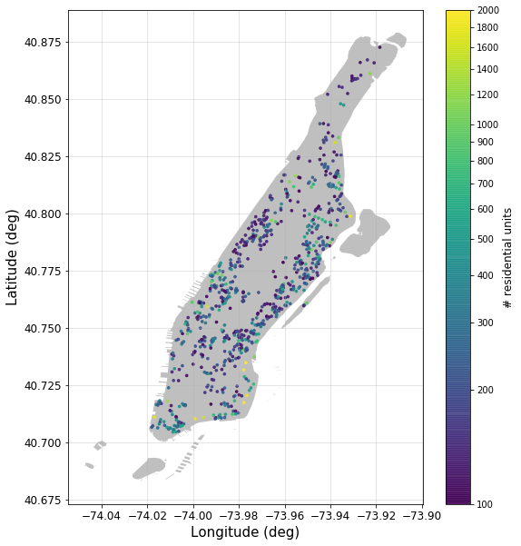

```python
selected_bldgs1 = select_data_question1(pluto_data)
manhattan_shp = load_manhattan_shp()
selected_bldgs1 = clear_bad_lat_lon(selected_bldgs1,manhattan_shp)
fig,ax = create_static_plot_q1(selected_bldgs1,manhattan_shp)
```

Unfortunately, the static plot above isn't super helpful. I can identify a few of the buildings, but can't identify many--no addresses are given and it's difficult to judge locations relative to well-known parts of Manhattan. To address this problem, I've created an interactive version of the plot (below). I think this one is much more useful--the BBL, address, and number of units are all available via a hover tool, and the building footprints are also available when you zoom in far enough. This makes learning from the plot much easier.

NOTE: The interactive plot is not displayed in the PDF version of this notebook.

```python
p = create_interactive_plot_q1(selected_bldgs1)
show(p)
```

[interactive chart not shown]

## Question 2

Create a line chart that shows the number of residential units in Brooklyn over time from 2012 to current day. Exclude one and two family dwellings.

I spotted a potential problem:

- 177/75616 of the multi-family residential buildings have `UnitsRes = 0`. This isn't a huge problem because it's less than 1% of the tax lots I'm interested in, but if I wanted to fix those values, maybe I could regress building square footage against the number of residences, and use that to estimate the number of residences from those buildings' square footage? Since the resulting correction would be very small, I don't think that's necessary here.

NOTE: I'm excluding units in apartment hotels and dormitories from the analysis because I'm not sure if those units qualify as "residential." However, I am including residential units in multiple-use residences for 3-6 families (`BldgClass in ['S3','S4','S5']`).

```python
selected_bldgs2 = select_data_question2(pluto_data)
annual_nums = selected_bldgs2.groupby('pluto_version_year')['UnitsRes'].sum().loc[2012:]
p = create_interactive_plot_q2(annual_nums)
show(p)
```

[interactive chart not shown]

## Question 3

In PLUTO, some BBLs have 0 in the YearBuilt field. Tell us what you think a possible cause or causes for the 0 values could be.

Possible causes:

1. **There's no building on the tax lot.** In the cell below, I've printed the ten most frequent `BldgClass` values for tax lots with `YearBuilt = 0`. The ten most common are: V0 (vacant land; zoned residential, not Manhattan), V1 (vacant land; zoned commercial or manhattan residential), G7 (unlicensed parking lot), Z9 (miscellaneous; other), Q0 (open space), Q1 (parks/recreation facilities), U7 (utility bureau properties; transportation-public ownership), U6 (raiload-private ownership), V9 (vacant land; miscellaneous), and G6 (licensed parking lots). Many tax lots with these functions probably won't have buildings, which suggests that the `YearBuilt` could be zero when there's no building on the tax lot.
2. **The building construction year is unavailable.** The data dictionary says that the `BldgArea` is set to zero when there is no building or when the square footage is unavailable, so it's possible that PLUTO uses the same convention when the building construction year isn't available.
3. **Someone made a mistake.** I'd imagine that humans originally entered a lot of this data, so mistakes are always possible. Since I didn't notice many typos elsewhere in the dataset, I'd imagine this is the least likely reason.

```python
pluto_data[(pluto_data['YearBuilt']==0) & (pluto_data['pluto_version_year']==2019)]\
                                                      ['BldgClass'].value_counts().head(10)
```

[output not shown]